# Changes in trading account

## Portfolio

| symbol | close | closePerc | Total_Change_close | entry_price | position | position_size | entry_position | totalPerc | book_proceed | sector |
| --- | --- | --- | --- | --- | --- | --- | --- | --- | --- | --- |
| BRK.B | 209.370 | 2.09 | 171.20 | 190.50387 | 40 | 8374.80 | 7620.1547 | 9.01 | 754.6453 | US Finance |
| EZA | 36.420 | -3.22 | 242.00 | 38.54000 | -200 | -7284.00 | -7708.0000 | 5.82 | 424.0000 | Emerging markets |
| KWEB | 67.930 | -4.67 | -333.00 | 70.61916 | 100 | 6793.00 | 7061.9165 | -3.96 | -268.9165 | Emerging markets |
| SEAS | 16.910 | 2.80 | -126.50 | 16.24424 | -275 | -4650.25 | -4467.1667 | -3.94 | -183.0833 | US Retail |
| CAKE | 25.830 | 2.99 | 112.50 | 23.14854 | 150 | 3874.50 | 3472.2814 | 10.38 | 402.2186 | US Retail |
| WPM | 52.860 | -4.58 | -152.40 | 55.66323 | 60 | 3171.60 | 3339.7940 | -5.30 | -168.1940 | Metals |
| TSLA | 1453.100 | -2.46 | -73.18 | 1425.00000 | 2 | 2906.20 | 2850.0000 | 1.93 | 56.2000 | US Tech |
| SLV | 26.180 | -2.53 | -74.80 | 21.80151 | 110 | 2879.80 | 2398.1657 | 16.72 | 481.6343 | Metals |
| LMND | 66.760 | -2.81 | -77.20 | 78.07124 | 40 | 2670.40 | 3122.8495 | -16.94 | -452.4495 | US Tech |
| JWN | 16.020 | 4.84 | 111.00 | 14.09993 | 150 | 2403.00 | 2114.9900 | 11.99 | 288.0100 | US Retail |
| V | 196.390 | -1.21 | -24.00 | 194.66399 | 10 | 1963.90 | 1946.6399 | 0.88 | 17.2601 | US Finance |
| GDX | 42.780 | -3.28 | -50.75 | 43.89279 | 35 | 1497.30 | 1536.2475 | -2.60 | -38.9475 | Metals |
| GOOG | 1493.960 | -0.49 | -7.39 | 1475.23040 | 1 | 1493.96 | 1475.2304 | 1.25 | 18.7296 | US Tech |
| SQ | 147.225 | -4.39 | -67.55 | 145.58699 | 10 | 1472.25 | 1455.8699 | 1.11 | 16.3801 | US Tech |
| TPR | 14.510 | 3.35 | 47.00 | 12.95000 | 100 | 1451.00 | 1295.0000 | 10.75 | 156.0000 | US Retail |
| SWKS | 144.250 | -2.63 | -39.00 | 131.84990 | 10 | 1442.50 | 1318.4990 | 8.60 | 124.0010 | US Tech |
| HD | 271.690 | 0.85 | 11.50 | 266.53990 | 5 | 1358.45 | 1332.6995 | 1.90 | 25.7505 | US Retail |
| PPLT | 90.450 | -3.77 | -53.10 | 89.43657 | 15 | 1356.75 | 1341.5485 | 1.12 | 15.2015 | Metals |
| RVLV | 17.690 | 3.75 | 48.00 | 15.91993 | 75 | 1326.75 | 1193.9950 | 10.01 | 132.7550 | US Tech |
| EPHE | 26.110 | 0.12 | -1.50 | 25.66800 | -50 | -1305.50 | -1283.4000 | -1.69 | -22.1000 | Emerging markets |
| CRUS | 64.620 | -0.68 | -8.80 | 71.60495 | 20 | 1292.40 | 1432.0990 | -10.81 | -139.6990 | US Tech |
| BBBY | 12.110 | 0.83 | -10.00 | 11.01000 | -100 | -1211.00 | -1101.0000 | -9.08 | -110.0000 | US Retail |
| PALL | 204.550 | -1.85 | -19.28 | 219.67990 | 5 | 1022.75 | 1098.3995 | -7.40 | -75.6495 | Metals |
| HLT | 83.690 | 1.16 | -9.60 | 74.54000 | -10 | -836.90 | -745.4000 | -10.93 | -91.5000 | US Retail |
| UPWK | 14.860 | 6.83 | 47.50 | 14.50000 | 50 | 743.00 | 725.0000 | 2.42 | 18.0000 | US Tech |
| FIZZ | 63.250 | 0.03 | 0.20 | 68.19990 | 10 | 632.50 | 681.9990 | -7.83 | -49.4990 | US Retail |
| NFLX | 494.980 | -2.76 | -14.07 | 486.00000 | 1 | 494.98 | 486.0000 | 1.81 | 8.9800 | US Tech |
| QQQ | 271.500 | -1.12 | -3.08 | 258.75990 | 1 | 271.50 | 258.7599 | 4.69 | 12.7401 | US Tech |

| symbol | close | closePerc | Total_Change_close | entry_price | position | position_size | entry_position | totalPerc | book_proceed | sector |
| --- | --- | --- | --- | --- | --- | --- | --- | --- | --- | --- |
| Summary | NA | NA | -354.3 | NA | 1635 | 66180.94 | NA | 2.04 | 1352.468 | NA |

[interactive chart not shown]

The performance of my live stock portfolio/trading account vs. my paper trading account and the benchmark ‘SPY’, the US large cap stock market index ETF in percent since June 09 2020.

[interactive chart not shown]

My current portfolio sorted by sectors. The plot reads clock-wise. Positions below 0 are short positions. Clicking a slice of the pie chart directs to marketwatch.com for further information.

[interactive chart not shown]

These two plots indicates the composition of my portfolio and the change of it over the past week.

[interactive chart not shown]

The inner circle is Monday, the outer circle is Friday.

[interactive chart not shown]

The colors in this plot indicate the daily percentage change of each stock in my portfolio.

[interactive chart not shown]

I classified the stocks in my portfolio by sector. The area represents the size of the position in the portfolio. Long postions

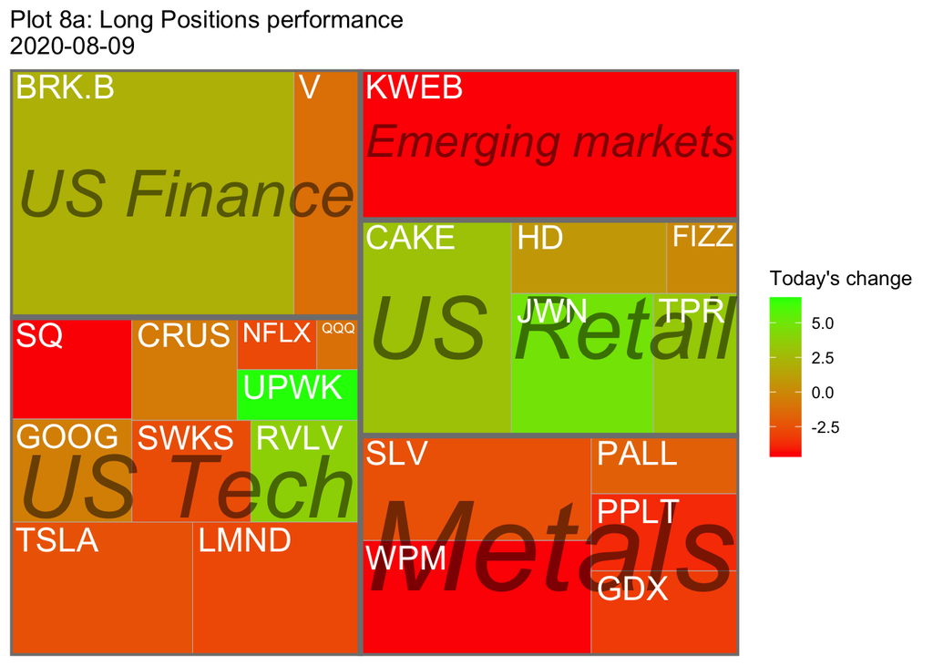

Short postions

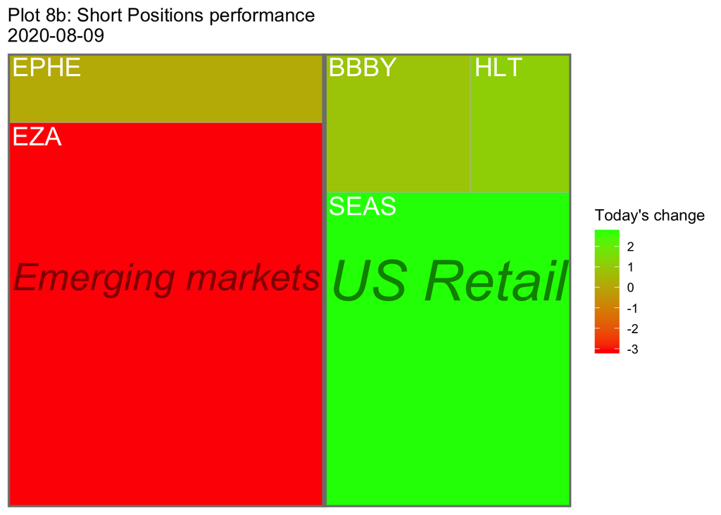

S&P 500 stocks colored by last day performance.

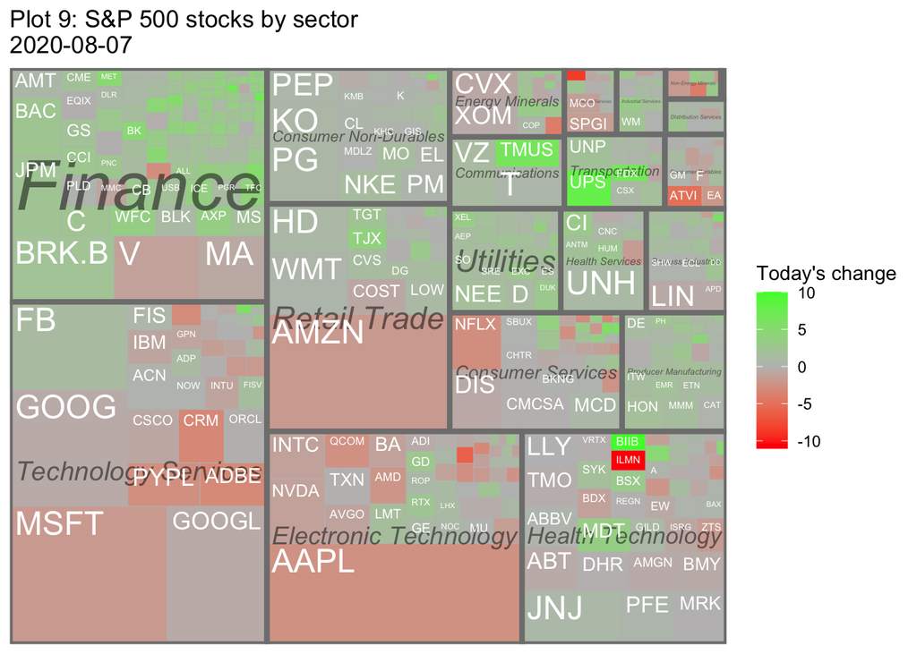

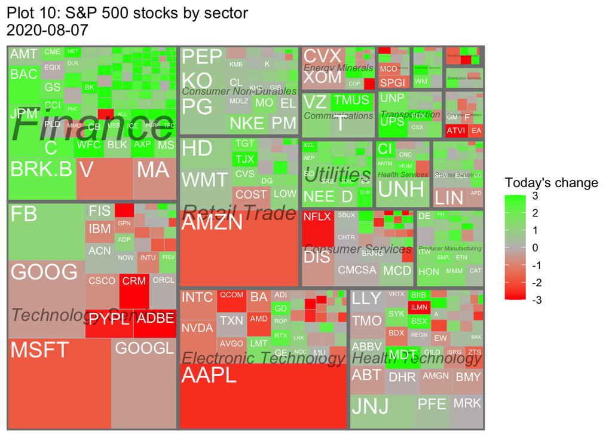

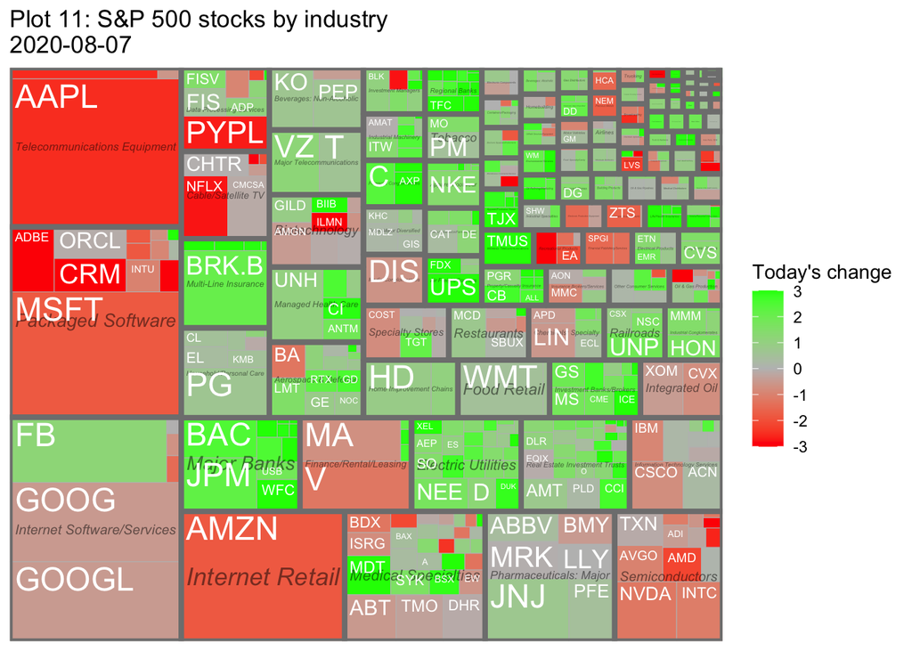